# Multiple Linear Regresion

## Introduction

**Multiple Linear Regression Analysis** is a common way to discover relations between two or more predictors with a response variable by fitting a linear equation. We will reserve the term multiple regression for models with two or more predictors and one response. This means that There are also regression models with two or more response variables. These models are usually called multivariate regression models.

Commonly Multiple Linear Regression is used either to **look for significant relationships between tow variables or to predict a value of one variable based on the values of the others**.

A multiple linear regression model with k predictor variables X1, X2, …, Xk and a response Y , can be written as

```r
#Installing the packages
install.packages("purrr")
install.packages ("dplyr")
install.packages("broom")
install.packages("RCurl")
install.packages("Ecdat")
```

```r
#Loading the libraries
library(purrr)
library(ggplot2)
library(dplyr)
library(broom)
library(knitr)
library(magrittr)
```

On this exercise we are going to work with Ecdat package and extramarital affairs data set that contains 9 variables with 601 observations.

First we are going to **visualize the data**, *the glimpse ()* function makes possible to see every column in a data frame. This data set was designed to developed a theory of extramarital affairs by Ray C. Fair at Yale University. So the variables used are designed to explain in a statistical way why it happens.

```r
data(Fair, package = "Ecdat")
glimpse(Fair)
```

[output not shown]

Since the main variable is the number of affairs in the past years, we are going to calculate the **R<sup>2</sup>** for each variable excluding nbafairs with dplyr.

```r
Fair %>%
  dplyr::select(-nbaffairs) %>%  # exclude outcome, leave only predictors
  map(~lm(Fair$nbaffairs ~ .x, data = Fair)) %>%
  map(summary) %>%
  map_dbl("r.squared") %>%
  tidy %>%
  dplyr::arrange(desc(x)) %>%
  rename(r.squared = x) -> r2s
kable(r2s)
```

| names | r.squared |
| --- | --- |
| rate | 0.0781272 |
| ym | 0.0349098 |
| religious | 0.0208806 |
| child | 0.0108181 |
| age | 0.0090701 |
| occupation | 0.0024613 |
| sex | 0.0001377 |
| education | 0.0000059 |

The function *lm ()* can be used to perform multiple linear regression in R and much of the syntax is the same as that used for fitting simple linear regression. To perform multiple linear regression with $n$ explanatory variables we are going to use the command:

$lm(response ~ predictor~1~ + predictor~2~ + … + explanatory~n~)$

```r
lm1 <- lm(nbaffairs ~ ym + education , data = Fair)
summary(lm1)
```

```
Call:
lm(formula = nbaffairs ~ ym + education, data = Fair)

Residuals:
    Min      1Q  Median      3Q     Max
-2.3099 -1.6875 -0.9814 -0.5927 11.3108

Coefficients:
            Estimate Std. Error t value Pr(>|t|)
(Intercept)  0.76966    0.91535   0.841    0.401
ym           0.11086    0.02380   4.657 3.95e-06 ***
education   -0.01363    0.05520  -0.247    0.805
---
Signif. codes:  0 ‘***’ 0.001 ‘**’ 0.01 ‘*’ 0.05 ‘.’ 0.1 ‘ ’ 1

Residual standard error: 3.246 on 598 degrees of freedom
Multiple R-squared:  0.03501,   Adjusted R-squared:  0.03178
F-statistic: 10.85 on 2 and 598 DF,  p-value: 2.358e-05
```

Finally, to observe the relation between the R<sup>2</sup> value of each predictor and the their variance we will use *ggplot*.

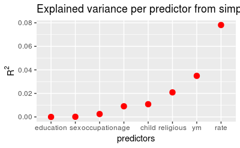

```r
ggplot(r2s, aes(x = reorder(names, r.squared), y = r.squared)) +
  geom_point(size = 3, color = "red") +
  ylab(expression(R^{2})) +
  xlab("predictors") +
  ggtitle("Explained variance per predictor from simple regressions")
```

https://sebastiansauer.github.io/multiple-lm-purrr2/